# Tarea_2_mercado

Prueba

mateo

2024-05-16

Un académico llamado Robert Schiller diseñó una razón modificada del P/E. Se conoce como “Cyclically adjusted price-to-earnings ratio” (CAPE) y lo que hace es calcular la razón precio utilidad (PE) pero con dos modificaciones: i) usando la utilidad promedio de los últimos 10 años y ii) ajustar por inflación. En el archivo Excel “Datos Tarea 2” encontrará los valores del ratio CAPE para el índice SP500 de manera mensual desde el año 1900 hasta hoy. Además de eso, cuenta con los valores del SP500 junto a los dividendos pagados por las empresas que componen el índice en el último año. Finalmente, también cuenta con las tasas (mensuales) de los bonos americanos a 10 años plazo. Siga las instrucciones y desarrolle los siguientes ítems:

**1.** Realice los siguientes gráficos:

**a)** (1 pto.| 1 pto. acumulado) Grafique el ratio CAPE a lo largo del tiempo, desde 1900/ene hasta 2022/abr. Etiquetelos meses en donde el ratio alcanzó valores elevados que le llamen la atención. (Ej. 1929-sept | 32,56)

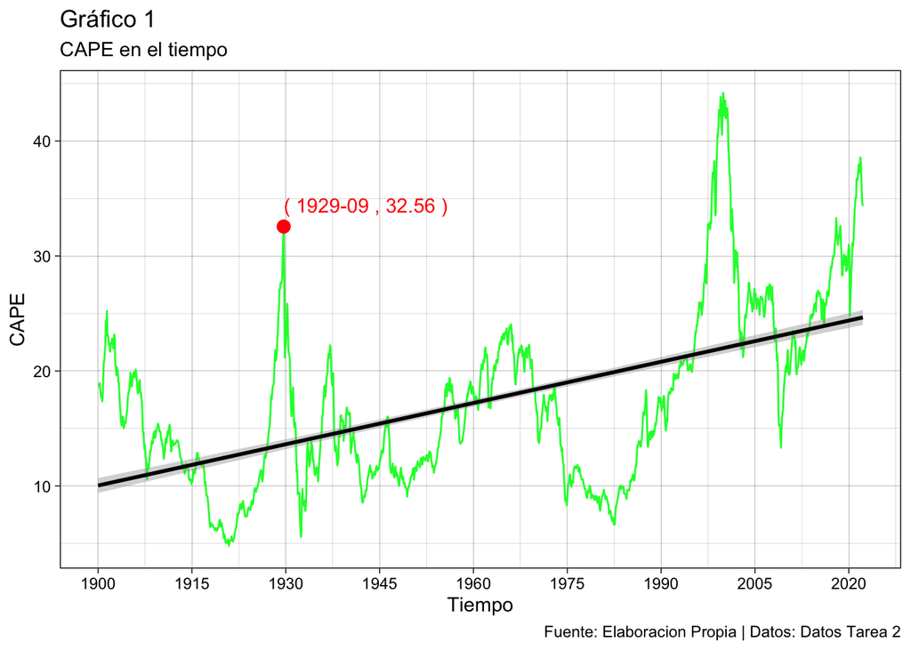

**b)** (1 pto.| 2 pts. acumulados) Grafique la evolución del SP 500, desde 1900/ene hasta 2022/abr.

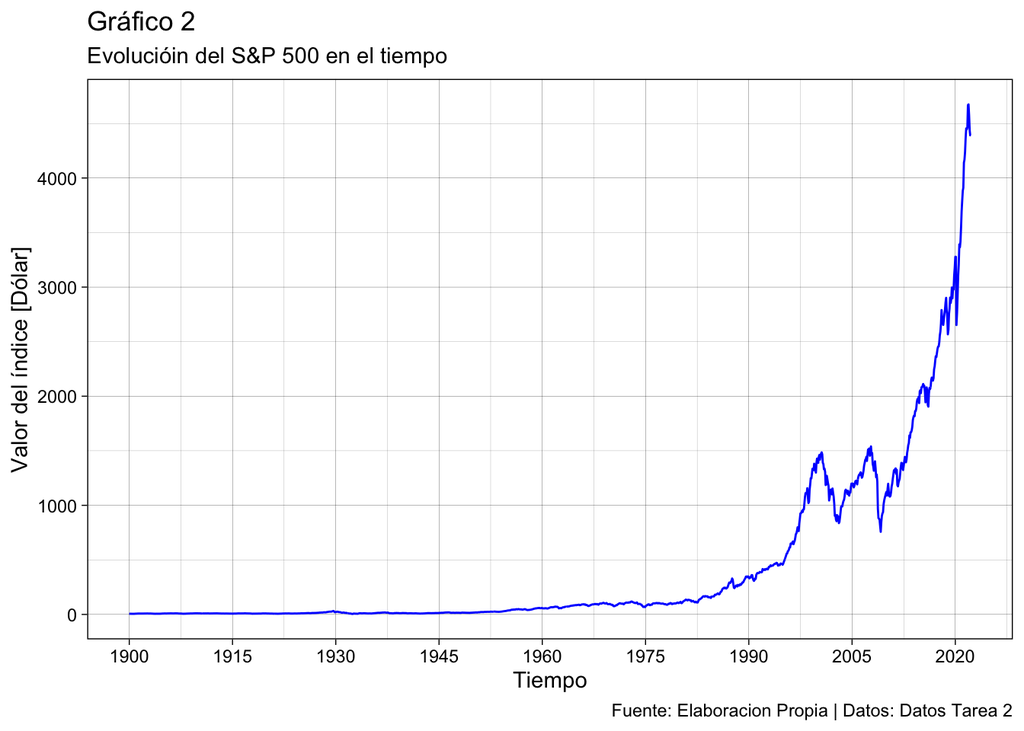

**c)** (2 pts.| 4 pts. acumulados) Grafique los retornos del SP500, desde 1900/ene hasta 2022/abr. Etiquete los meses con mayores caídas. (Ej. 1929/nov | -26,47%)

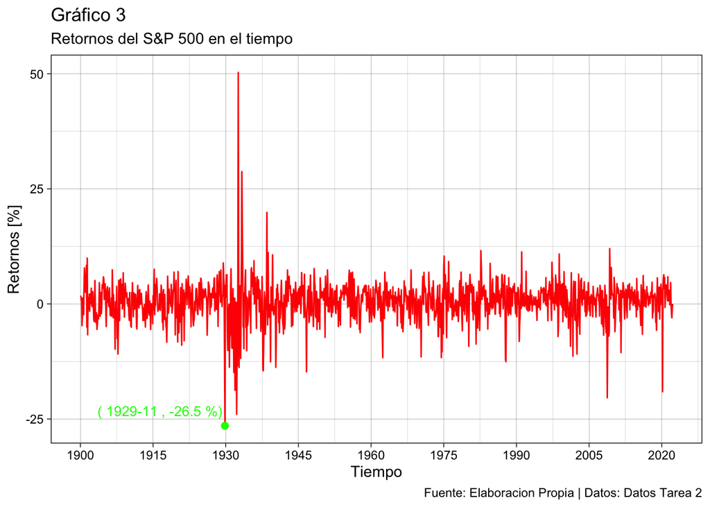

A partir de los gráficos realizados, comente sobre si le parece que hay alguna relación entre CAPE y caídas fuertes de mercado.

**2.** Suponga que en 1980/abr nacieron dos amigas: Belen y Sara. Sus padres sabían de inversiones y del poder del interés compuesto, y decidieron invertir $1000 USD a nombre de sus hijas en ese mismo mes. Los padres de Belen invirtieron los $1000 USD en un portafolio de bonos a 10 años plazo, mientras que los padres de Sara invirtieron los $1000 USD en un portafolio que replica el SP500. En ambos casos, los ingresos que se iban recibiendo, tanto pagos de intereses como de dividendos, se fueron reinvirtiendo en los portafolios.

**a)** (1 pto.| 5 pts. acumulados) Muestre en un solo gráfico la evolución de ambos portafolios desde 1980/abr hasta 2022/abr.

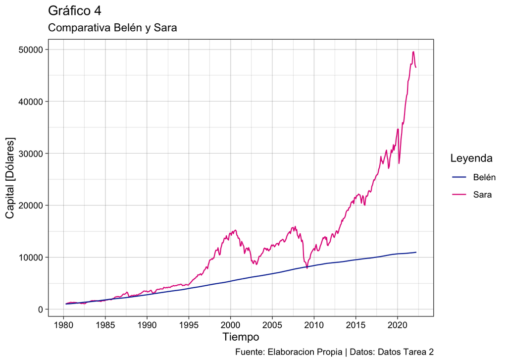

|  | Date | SP500 | SP500.Dividends..anual. | CAPE | Tasas.Bono.10Y..mensual. | SP500.Retorno | Belen | Ret.Belen | Sara | Ret.Sara | Cant.acc | Dividendo.sa | Compra.acc |
| --- | --- | --- | --- | --- | --- | --- | --- | --- | --- | --- | --- | --- | --- |
| 964 | 1980-04-01 | 103 | 0.040601875 | 7.844024504719216 | 0.009558333333333334 | -0.0162368672397326 | 1000 |  | 1000 |  | 9.70873786407767 | 0.3941929611650485 | 0.003827116127816005 |
| 965 | 1980-05-01 | 107.7 | 0.04092590277777778 | 8.104225807176496 | 0.008483333333333332 | 0.04563106796116508 | 1008.483333333333 | 0.008483333333333348 | 1046.028406823085 | 0.04602840682308534 | 9.712427175701812 | 0.3973388619201726 | 0.003689311624142735 |
| 966 | 1980-06-01 | 114.6 | 0.04125 | 8.51207796230674 | 0.00815 | 0.06406685236768794 | 1016.7024725 | 0.008150000000000096 | 1113.444791956425 | 0.06444986072423388 | 9.715923140981024 | 0.4006376209976998 | 0.00349596527921204 |
| 967 | 1980-07-01 | 119.8 | 0.04155090277777777 | 8.88086552729584 | 0.008541666666666666 | 0.04537521815008728 | 1025.386806119271 | 0.008541666666666607 | 1164.371297667354 | 0.04573779147275539 | 9.719292968842687 | 0.4037053778272638 | 0.003369827861663304 |
| 968 | 1980-08-01 | 123.5 | 0.041851875 | 9.071005981618383 | 0.00925 | 0.03088480801335562 | 1034.871634075874 | 0.009250000000000083 | 1200.739452286492 | 0.03123415588480818 | 9.72258665819022 | 0.4067706344203831 | 0.003293689347533466 |
| 969 | 1980-09-01 | 126.5 | 0.04215277777777778 | 9.196040131743239 | 0.009591666666666667 | 0.0242914979757085 | 1044.797777832719 | 0.009591666666666582 | 1230.317046295891 | 0.0246328160143948 | 9.725826452931942 | 0.4098340348278794 | 0.003239794741722367 |
| 970 | 1980-10-01 | 130.2 | 0.04236111111111111 | 9.35784104675711 | 0.009791666666666666 | 0.02924901185770742 | 1055.028089407331 | 0.009791666666666594 | 1266.714600986759 | 0.02958388230127342 | 9.728990790988933 | 0.4119968150200336 | 0.003164338056989506 |
| 971 | 1980-11-01 | 135.7 | 0.04256944444444444 | 9.65404366323339 | 0.01056666666666667 | 0.04224270353302612 | 1066.176219552068 | 0.01056666666666669 | 1320.638208070176 | 0.04256965779143208 | 9.732042800811906 | 0.414157732977515 | 0.003052009822973581 |
| 972 | 1980-12-01 | 133.5 | 0.04277777777777778 | 9.389902084921742 | 0.0107 | -0.01621223286661745 | 1077.584305101275 | 0.01069999999999992 | 1299.644029072646 | -0.01589699500532214 | 9.73516126646177 | 0.4163151642569537 | 0.003118465649864822 |
| 973 | 1981-01-01 | 133 | 0.04305555555555556 | 9.259404530877955 | 0.010475 | -0.003745318352059925 | 1088.872000697211 | 0.01047500000000007 | 1295.195601216166 | -0.003422804827299265 | 9.738312791098991 | 0.4191527767504374 | 0.003151524637221334 |

[output cut: 495 more lines]

**b)** (2 pts.| 7 pts. acumulados) Determine la rentabilidad realizada (anual) y volatilidad (anual) de ambos portafolios.

**c)** (1 pto.| 8 pts. acumulados) Comente los resultados.

**3.** Analice que hubiese pasado si se invertía ese dinero de acuerdo a una estrategia basada en el ratio CAPE. La estrategia es la siguiente: Mes a mes se invierte el 100% de su patrimonio en el SP500 si la razón CAPE esté dentro de una zona favorable (umbral definido a su criterio) o 100% en bonos en caso contrario. Por ejemplo, en 1980/abr debe invertir los $1000 USD en el SP500 si es que el CAPE de 1980/mar es menor al umbral que definió; en caso contrario los invierte en bonos.

*a)* (1 pto.| 9 pts. acumulados) Realice un gráfico que muestre la evolución del portafolio CAPE junto al portafolio de Sara (SP500)

[figure not shown]

```
## La media del CAPE desde el 1980 es  22.96144
```

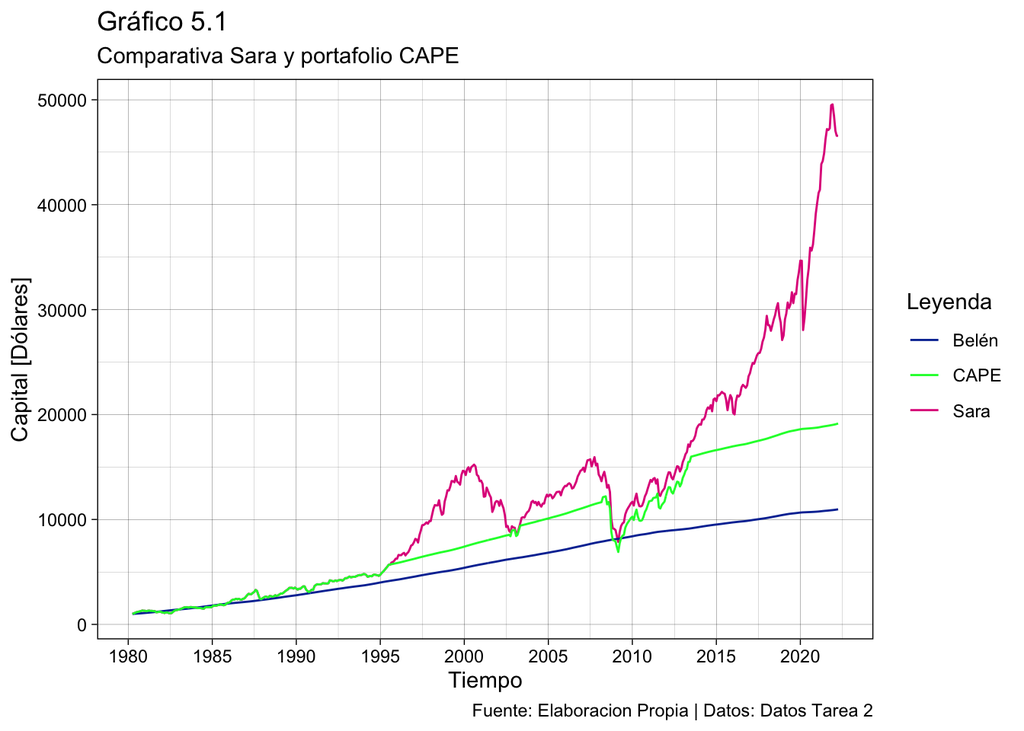

El umbral del cape es su media del periodo, la cual corresponde a 22.961, El capital final del Portafolio de Sara es de $46570.87 Mientras que el capital final del Portafolio CAPE es de $19147.2. La diferecia de capitales es de $27423.67 quedando mejor Sara.

*b)* (2 pts.| 11 pts. acumulados) Comente los resultados.

*c)* (1 pto.| 12 pts. acumulados) Analice que hubiese pasado si se elegia otro umbral. Hint: Puede utilizar “análisis de hipótesis: tabla de datos” de Excel para analizar qué hubiese pasado con el valor final del portafolio para distintos umbrales. Comente sus resultados.

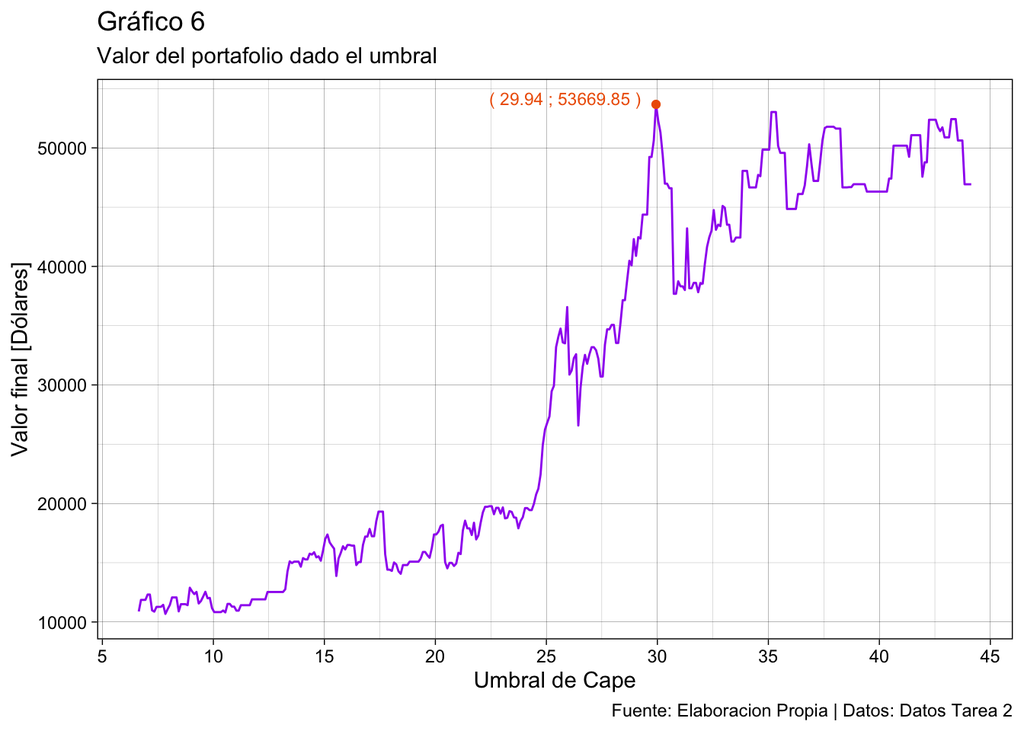

|  | Umbral | F.Port |
| --- | --- | --- |
| 1 | 6.638653100208761 | 10887.24852323229 |
| 2 | 6.738653100208761 | 11863.08644439923 |
| 3 | 6.838653100208761 | 11863.08644439923 |
| 4 | 6.938653100208761 | 11863.08644439923 |
| 5 | 7.038653100208761 | 12314.64014051941 |
| 6 | 7.138653100208761 | 12314.64014051941 |
| 7 | 7.238653100208762 | 10981.14444588841 |
| 8 | 7.338653100208761 | 10871.63907522141 |
| 9 | 7.438653100208761 | 11274.62564340314 |
| 10 | 7.538653100208761 | 11274.62564340314 |

[output cut: 366 more lines]

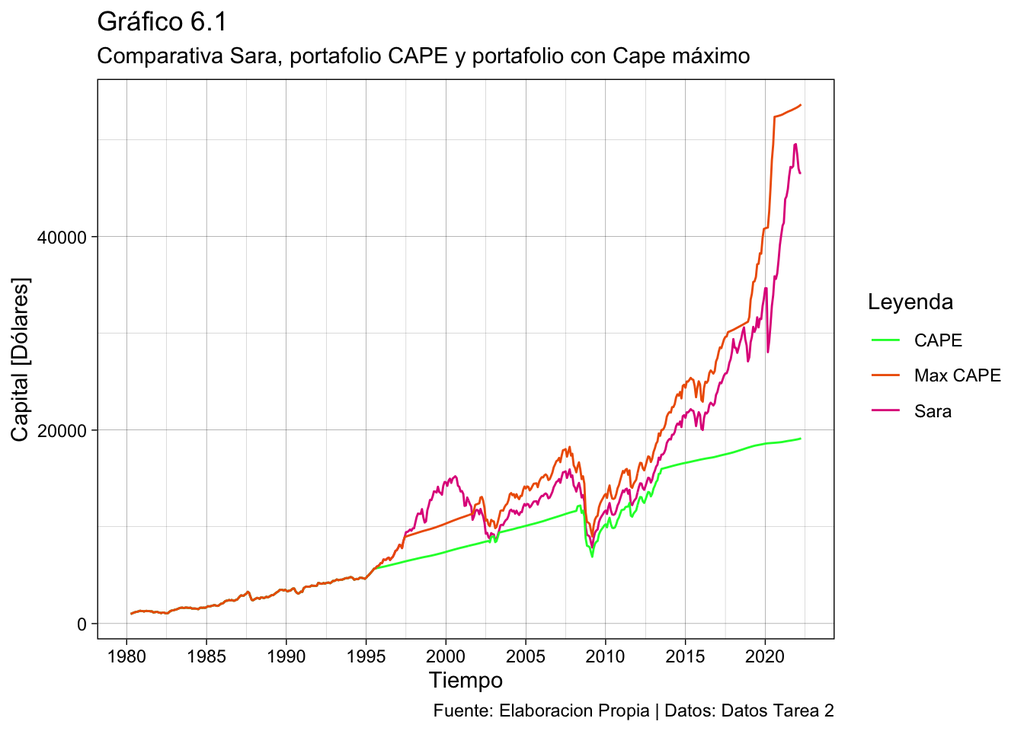

Los valoraciones finales del portafolio van mejorando a medida que el umbral va aumentando, sin embargo hay calores en los que decae, no obstante el mejor valor es cuando el umbral es 29.939 y obtiene un valor final de portafolio de $53669.85

**4.** (3 pts.| 15 pts. acumulados) Suponga que usted quiere aplicar alguna de las estrategias en la práctica. Sin embargo,usted se da cuenta que es complicada la implementación de invertir y vender 500 acciones. ¿Existen instrumentos transables o disponibles en donde esta dificultad no exista, y por tanto se haga más fácil la implementación de esta estrategia? Explique como lo haría.

1. Una de las primeras opciones como alternativa son los fondos de inversión indexados (ETFs): Existen ETFs que siguen al SP500 , esto quiere decir que intentan replicar su rendimiento. Al invertir en ETFs , se invierte en una portafolio de diversas acciones que componen este indice. Esta alternativa puede simplificar la estrategia, ya que solo se necesitaria comprar y vender acciones de un solo ETF en lugar de las 500 acciones individuales.
2. Otra posible alternativa es invertir en fondos mutuos del S&P500: Al igual que los fondos de inversión indexados (ETFs), los fondos mutuos que siguen al S&P500 invierten en un portafolio de acciones que componen el indice. Esto significa que se puede comprar y vender participaciones del fondo mutuo en lugar de acciones individuales, lo que consideramos que simplificaria la ejecución de la estrategia.

**5.** (4 pts.| 19 pts. acumulados) Suponga ahora que cuando Sara cumplió 23 años (2003/abr) comenzó a generar ingresos, y fue ahorrando cada mes 170 USD que los fue invirtiendo en su portafolio (SP500). Calcule cuánto dinero tendría hoy en día con ese ahorro constante. Hint: En 2003/abr (al final) el portafolio tendrá un valor X producto de la rentabilidad generada de la inversión inicial de 1000 USD. El valor del portafolio en el siguiente periodo considerando el ahorro se obtiene:

𝑃𝑜𝑟𝑡𝑓𝑜𝑙𝑖𝑜2003/𝑚𝑎𝑦2003/𝑚𝑎𝑦= 𝑋 ∗ (1 + 𝑟 𝑆𝑃500 2003/𝑚𝑎𝑦) + 170

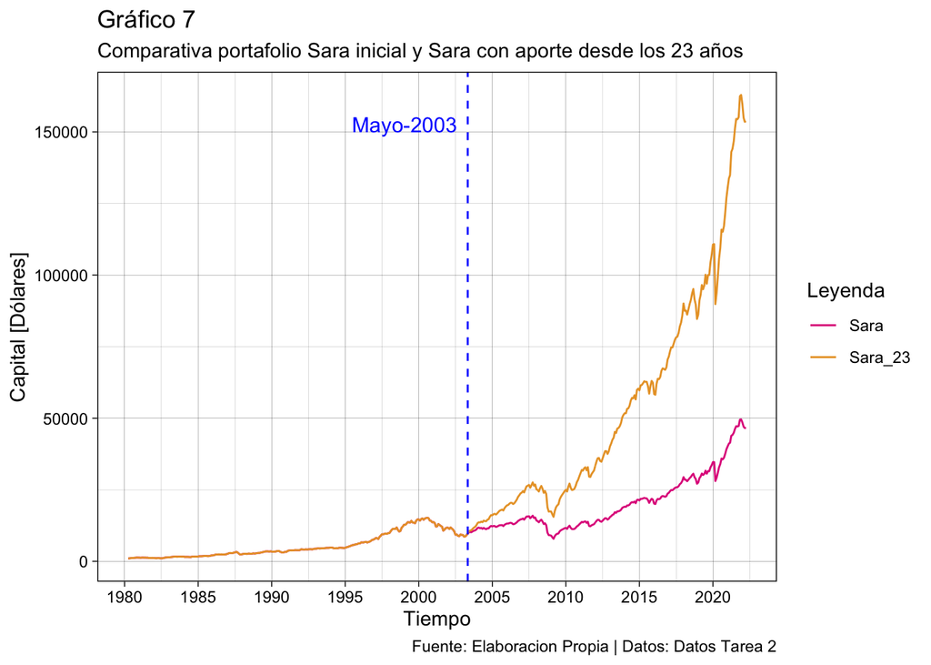

**6.** (3 ptos| 22 pts. acumulados) Considere que hoy en día Sara tiene 42 años, y está evaluando la opción de invertir su riqueza acumulada (pregunta anterior) de tal forma que esta inversión le genere un flujo de efectivo mensual, trimestral, semestral o anual, que tiene pensando utilizar para viajar. Explique en qué podría invertir ese dinero y estime cuánto efectivo aproximadamente podría generarle este portafolio al año.

Asumiendo que Sara no quiera estar preocupada de monitorear activos de renta variable, y quisiera asegurar ingresos fijos con un minimo riesgo en invirtiendo todo el capital acumulado, sería prudente optar por una inversión en renta fija o en bonos. Dicho esto, suponiendo un bono en el que se estimó su tasa de emision como un promedio de estas a lo largo del tiempo que ella ha vivido (desde 1980), se obtendría un valor esperado mensual de $734.35 de manera fija, por lo cual podría viajar tranquilamente.

**7.** Por último, usted decide crear un portafolio compuesto de 7 acciones elegidas por usted, todas con igual ponderación de inversión, donde quiere implementar lo que sabe de optimización de portafolios, para esto usted debe:

*a)* (1 pto.| 23 pts. acumulados) Obtener retornos y volatilidad de los retornos de cada activo Los retornos de los activos son:

|  | INTC | APPL | AMZN | MSFT | META | GOOG | NFLX | SyP500 |
| --- | --- | --- | --- | --- | --- | --- | --- | --- |
| 2018-01-03 | -0.03393810468246161 | -0.0001741482657233728 | 0.01277531038348645 | 0.004653886446555511 | 0.0179142323492556 | 0.01641315585570724 | 0.01979407958702395 | 0.006398818768781567 |
| 2018-01-04 | -0.01833844558413378 | 0.004644969352628925 | 0.004476012896857506 | 0.008801414587844336 | -0.001841102189103716 | 0.00362129819522905 | 0.002828587283211448 | 0.004028636080503967 |
| 2018-01-05 | 0.006977298473142213 | 0.01138531604115589 | 0.0161625165301762 | 0.01239813825608382 | 0.01367115633607274 | 0.01457106215021109 | 0.02120313430346066 | 0.007033767443369587 |
| 2018-01-08 | 0 | -0.003714250837053568 | 0.01442467883225085 | 0.001020482315446269 | 0.007653158303827068 | 0.00427316143828782 | 0.009809979069031582 | 0.001662343931643662 |
| 2018-01-09 | -0.02503358749584228 | -0.0001147362877008673 | 0.004675709574034626 | -0.0006796279952806517 | -0.002177627282598293 | -0.000614313271785738 | -0.01292150650191348 | 0.001302931596091295 |
| 2018-01-10 | -0.02567627141930262 | -0.0002294989072543219 | 0.001301205544250061 | -0.004534136480889517 | -0.0001596783950420511 | -0.003299385909116603 | 0.01533613659791189 | -0.001112226828252849 |
| 2018-01-11 | 0.02141176111557908 | 0.00568021992828216 | 0.01781828254348916 | 0.002960625565178621 | -0.0003726153470733351 | 0.00263919574484861 | 0.02220967968103293 | 0.007033646478779465 |
| 2018-01-12 | -0.003916106186198198 | 0.01032632115015475 | 0.0223392316104627 | 0.01725700058433133 | -0.04473562850371315 | 0.01514215882213943 | 0.01836673786357723 | 0.006749602987881076 |
| 2018-01-16 | -0.002312726293629219 | -0.005082127252220237 | -0.0002605871874575838 | -0.01395089309472519 | -0.005463543258162007 | -0.000445488775219216 | 0.001356068605304683 | -0.003524487622672101 |
| 2018-01-17 | 0.02897542924629581 | 0.01651628141089967 | -0.00755630863716783 | 0.02026033895237322 | -0.004428461734602429 | 0.00911064328942679 | -0.01819166163275177 | 0.009415051560751175 |

[output cut: 996 more lines]

*b)* (1 pto.| 24 pts. acumulados) Obtener la matriz de covarianza y correlación entre activos

Matriz de Covarianza

|  | INTC | APPL | AMZN | MSFT | META | GOOG | NFLX |
| --- | --- | --- | --- | --- | --- | --- | --- |
| INTC | 0.0005672454456050463 | 0.0002752589387035718 | 0.0002155205861662958 | 0.0002810315763558603 | 0.0002446317181136617 | 0.0002401262061357581 | 0.0002485226612172863 |
| APPL | 0.0002752589387035718 | 0.0004296629497442926 | 0.0002633987416175469 | 0.0002949706764982931 | 0.000283605766268222 | 0.0002554345483472558 | 0.0002588292696638537 |
| AMZN | 0.0002155205861662958 | 0.0002633987416175469 | 0.0003861295928779717 | 0.000263463887950907 | 0.0002735668162686787 | 0.000241506529986747 | 0.0003174714848576013 |
| MSFT | 0.0002810315763558603 | 0.0002949706764982931 | 0.000263463887950907 | 0.0003539072008106918 | 0.0002716663306098723 | 0.0002725125435258953 | 0.0002715887680343862 |
| META | 0.0002446317181136617 | 0.000283605766268222 | 0.0002735668162686787 | 0.0002716663306098723 | 0.0005160628217263926 | 0.0002837358338514189 | 0.0002829728633001363 |
| GOOG | 0.0002401262061357581 | 0.0002554345483472558 | 0.000241506529986747 | 0.0002725125435258953 | 0.0002837358338514189 | 0.0003378662716795936 | 0.0002473628131257464 |
| NFLX | 0.0002485226612172863 | 0.0002588292696638537 | 0.0003174714848576013 | 0.0002715887680343862 | 0.0002829728633001363 | 0.0002473628131257464 | 0.0006438149881787051 |

*c)* (2 pts.| 26 pts. acumulados) Obtener retorno y volatilidad del portafolio

*d)* (3 pts.| 29 pts. acumulados) Optimice su portafolio como usted desee (minimizando varianza, maximizando retorno, etc) y comente sus resultados comparándolo con el portafolio sin optimizar.

naturalmente el portafolio de minima varianza tiene una desviacion standard mas pequeña y a su vez menor retorno

*e)* (1 pto.| 30 pts. acumulados) Mencionar si dejaría alguna acción fuera su portafolio y mencione su criterio de decisión.

Hint: Obtenga los precios de cierre ajustados mensuales entre las fechas 01-01-2018 hasta el 31-12-2021. Puede obtener esta información a través de la página Yahoo, introduzca el ticker de la compañía y vaya a “Historical prices”, luego poner fechas que quiere ver, frecuencia de los datos y descargar.